# Explore & Summarize: Red Wine Dataset by Andy

## Dataset Introduction:

> The Red Wine Quality data set contains information about over 1,500 red wines with 11 variables that describe the chemical characteristics of wine. The data set provides a rating of the quality of each wine, with 0 being the lowest quality and 10 being the greatest quality.

### Dataset Questions to be Answered:

> Items that interest my within this red wine dataset how the higher rated wines compare to the lower ranked wines. What characteristics do they share, what are the major differences between them, does alcohol content, the amount of sugar and density matter?

Have quick view of the data

```
##   X fixed.acidity volatile.acidity citric.acid residual.sugar chlorides
## 1 1           7.4             0.70        0.00            1.9     0.076
## 2 2           7.8             0.88        0.00            2.6     0.098
## 3 3           7.8             0.76        0.04            2.3     0.092
## 4 4          11.2             0.28        0.56            1.9     0.075
## 5 5           7.4             0.70        0.00            1.9     0.076
## 6 6           7.4             0.66        0.00            1.8     0.075
##   free.sulfur.dioxide total.sulfur.dioxide density   pH sulphates alcohol
## 1                  11                   34  0.9978 3.51      0.56     9.4
## 2                  25                   67  0.9968 3.20      0.68     9.8
## 3                  15                   54  0.9970 3.26      0.65     9.8
## 4                  17                   60  0.9980 3.16      0.58     9.8
## 5                  11                   34  0.9978 3.51      0.56     9.4
## 6                  13                   40  0.9978 3.51      0.56     9.4
##   quality
## 1       5
## 2       5
## 3       5
## 4       6
## 5       5
## 6       5
```

Demonstrates that there are 1599 observations with 13 variables within this dataset

```
## 'data.frame':    1599 obs. of  13 variables:
##  $ X                   : int  1 2 3 4 5 6 7 8 9 10 ...
##  $ fixed.acidity       : num  7.4 7.8 7.8 11.2 7.4 7.4 7.9 7.3 7.8 7.5 ...
##  $ volatile.acidity    : num  0.7 0.88 0.76 0.28 0.7 0.66 0.6 0.65 0.58 0.5 ...
##  $ citric.acid         : num  0 0 0.04 0.56 0 0 0.06 0 0.02 0.36 ...
##  $ residual.sugar      : num  1.9 2.6 2.3 1.9 1.9 1.8 1.6 1.2 2 6.1 ...
##  $ chlorides           : num  0.076 0.098 0.092 0.075 0.076 0.075 0.069 0.065 0.073 0.071 ...
##  $ free.sulfur.dioxide : num  11 25 15 17 11 13 15 15 9 17 ...
##  $ total.sulfur.dioxide: num  34 67 54 60 34 40 59 21 18 102 ...
##  $ density             : num  0.998 0.997 0.997 0.998 0.998 ...
##  $ pH                  : num  3.51 3.2 3.26 3.16 3.51 3.51 3.3 3.39 3.36 3.35 ...
##  $ sulphates           : num  0.56 0.68 0.65 0.58 0.56 0.56 0.46 0.47 0.57 0.8 ...
##  $ alcohol             : num  9.4 9.8 9.8 9.8 9.4 9.4 9.4 10 9.5 10.5 ...
##  $ quality             : int  5 5 5 6 5 5 5 7 7 5 ...
```

View each variable’s max, min, median, mean

```
##        X          fixed.acidity   volatile.acidity  citric.acid
##  Min.   :   1.0   Min.   : 4.60   Min.   :0.1200   Min.   :0.000
##  1st Qu.: 400.5   1st Qu.: 7.10   1st Qu.:0.3900   1st Qu.:0.090
##  Median : 800.0   Median : 7.90   Median :0.5200   Median :0.260
##  Mean   : 800.0   Mean   : 8.32   Mean   :0.5278   Mean   :0.271
##  3rd Qu.:1199.5   3rd Qu.: 9.20   3rd Qu.:0.6400   3rd Qu.:0.420
##  Max.   :1599.0   Max.   :15.90   Max.   :1.5800   Max.   :1.000
##  residual.sugar     chlorides       free.sulfur.dioxide
##  Min.   : 0.900   Min.   :0.01200   Min.   : 1.00
##  1st Qu.: 1.900   1st Qu.:0.07000   1st Qu.: 7.00
##  Median : 2.200   Median :0.07900   Median :14.00
##  Mean   : 2.539   Mean   :0.08747   Mean   :15.87
##  3rd Qu.: 2.600   3rd Qu.:0.09000   3rd Qu.:21.00
##  Max.   :15.500   Max.   :0.61100   Max.   :72.00
##  total.sulfur.dioxide    density             pH          sulphates
##  Min.   :  6.00       Min.   :0.9901   Min.   :2.740   Min.   :0.3300
##  1st Qu.: 22.00       1st Qu.:0.9956   1st Qu.:3.210   1st Qu.:0.5500
##  Median : 38.00       Median :0.9968   Median :3.310   Median :0.6200
##  Mean   : 46.47       Mean   :0.9967   Mean   :3.311   Mean   :0.6581
##  3rd Qu.: 62.00       3rd Qu.:0.9978   3rd Qu.:3.400   3rd Qu.:0.7300
##  Max.   :289.00       Max.   :1.0037   Max.   :4.010   Max.   :2.0000
##     alcohol         quality
##  Min.   : 8.40   Min.   :3.000
##  1st Qu.: 9.50   1st Qu.:5.000
##  Median :10.20   Median :6.000
##  Mean   :10.42   Mean   :5.636
##  3rd Qu.:11.10   3rd Qu.:6.000
##  Max.   :14.90   Max.   :8.000
```

# Univariate Plots Section

### I want first take a quick view at all the variables to determine the best analysis for this dataset.

### Fixed Acidity

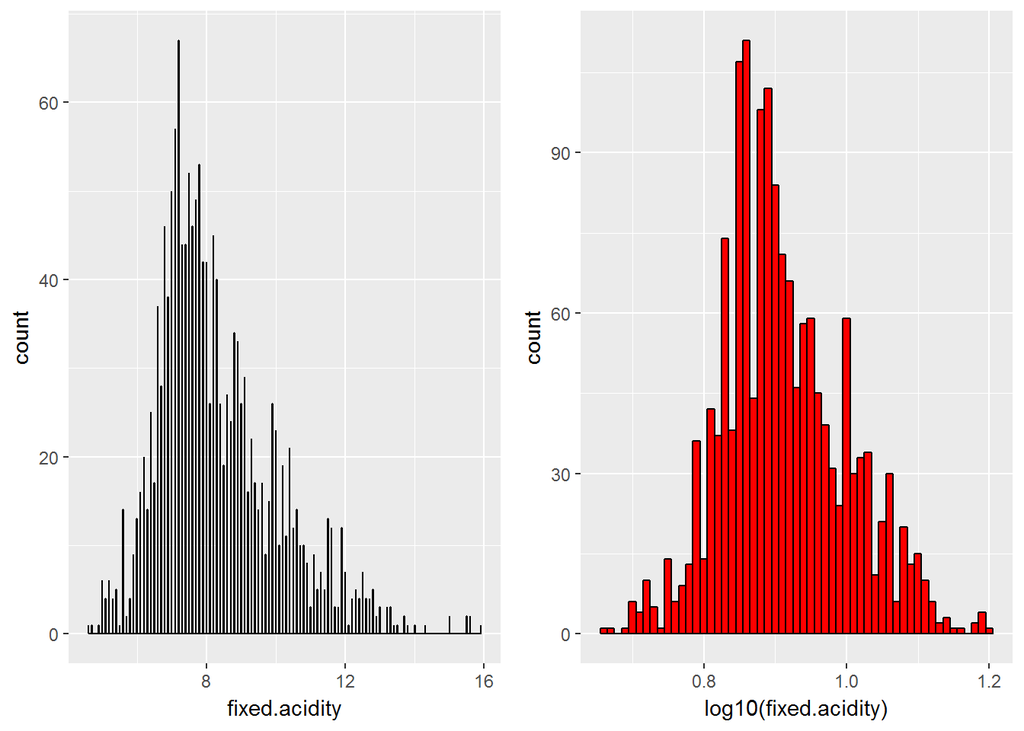

The graph is right-skewed. The data is mostely between 7 & 8, with a few outliers. The graph is a normal distribution curve when the log transformation is implemented.

### Volatile Acidity

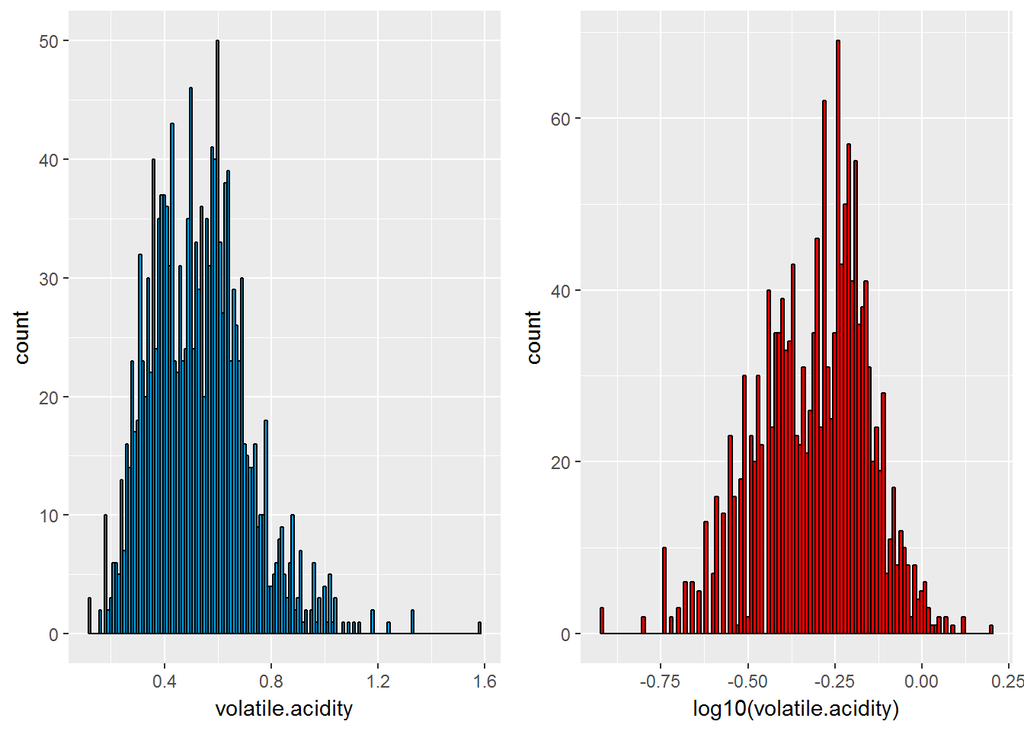

Within the volatile acidity data, there are outliers, therefore a log transformation was implemented. The mean of the volatile acidity is 0.5278.

### Citric Acid

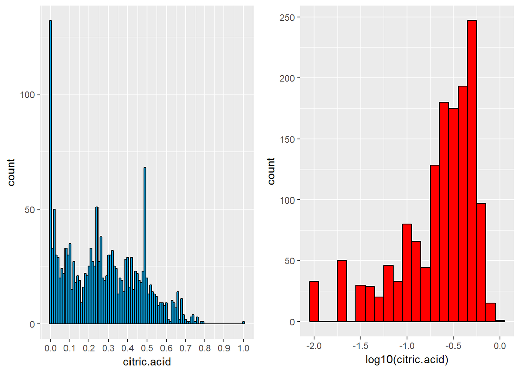

The bulk of the observations land between 0 and 0.5 with the bulk of the data at/around 0, with a very small percentage of outliers between 0.8 & 1. Even with adding the log distribution, the graph is still not a normal distribution curve.

### Sugar

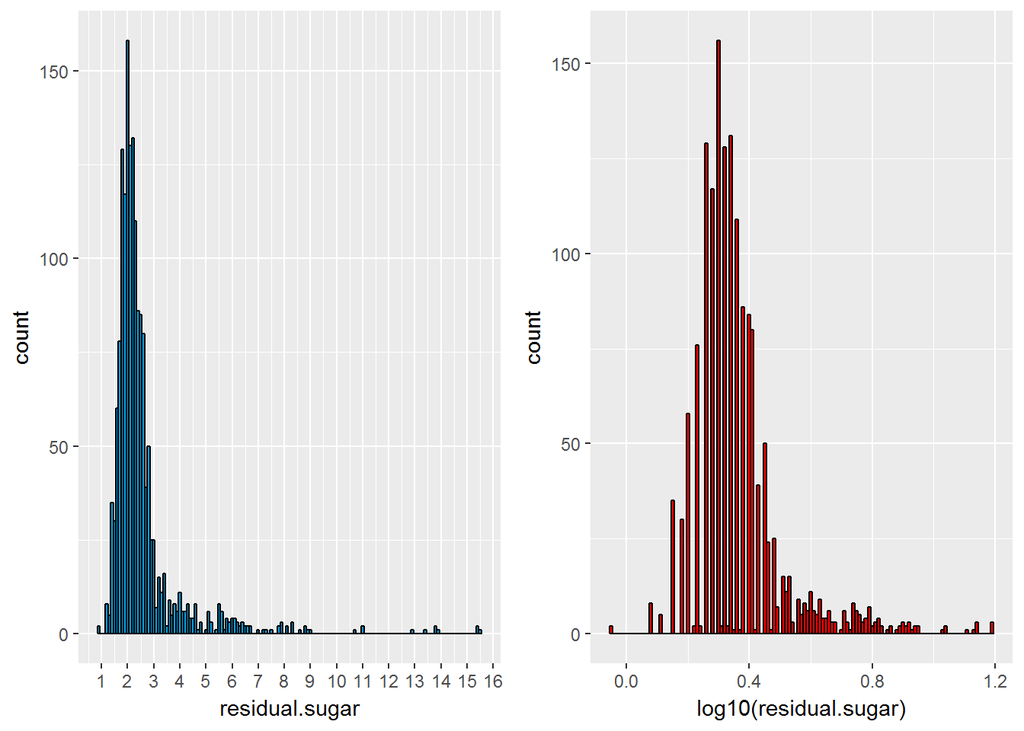

### Chlorides

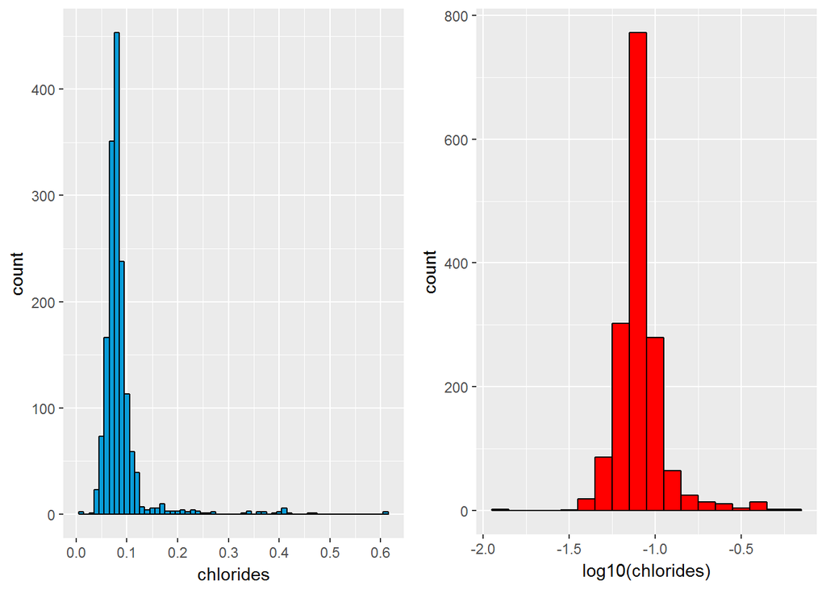

This graph is very similar to the sugar graph, with the bulk of the observations at .1 and extreme outliers. After the log10 distribution, it is a normal distribution curve.

### Free Sulfur Dioxide

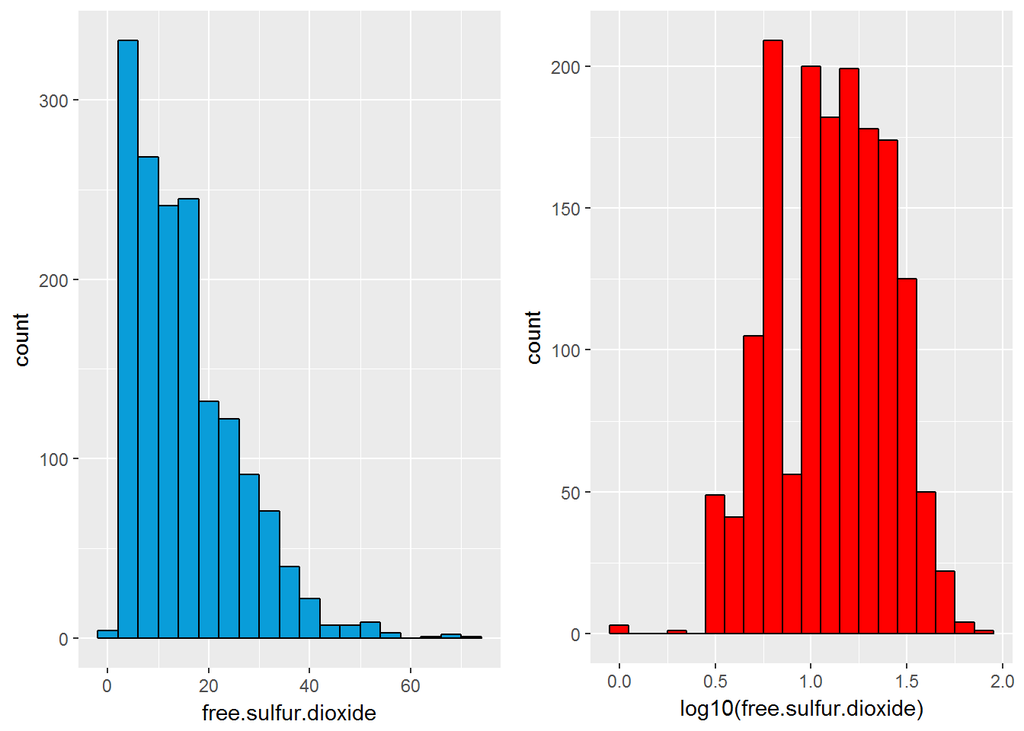

This is similar to the 2 previous charts with the observations being right skewed with a few outliers. After applying the log transformation, we still do not have a normal distribution curve.

### Total Sulfur Dioxide

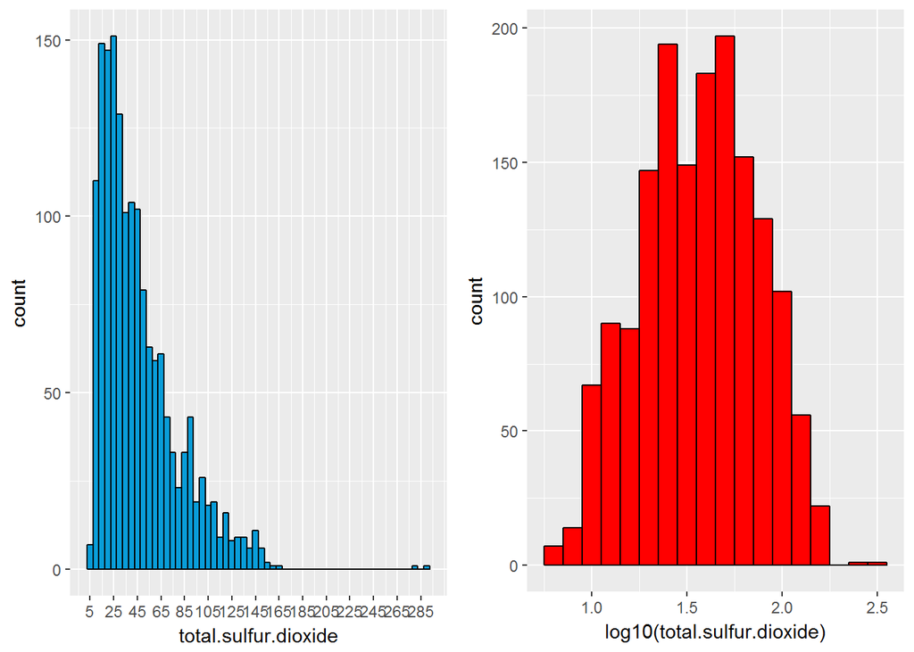

This graph is another that is right skewed with bulk of the data between 10 & 30 with a small number of extreme outliers. I used log for this due to the extreme outliers, now it is a normal distribution curve.

### Density

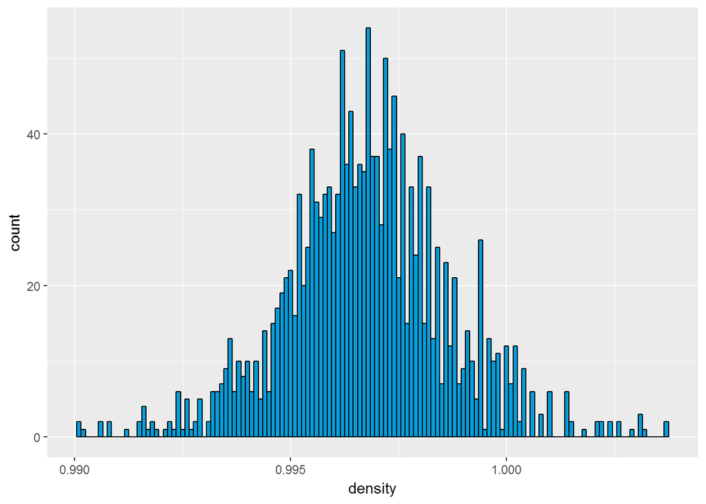

This graph is unlike the previous with a normal distribution curve.

### pH

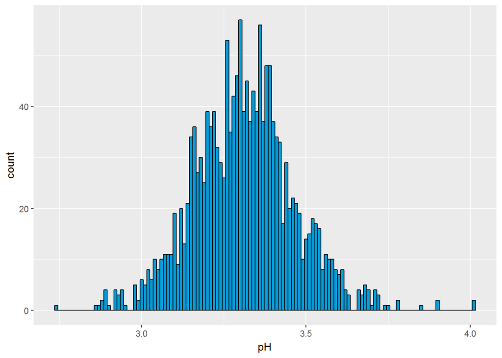

This graph is another example of a Normal Distribution Curve, with the mean at 3.311. There are a few outliers but not extreme.

### Sulphates

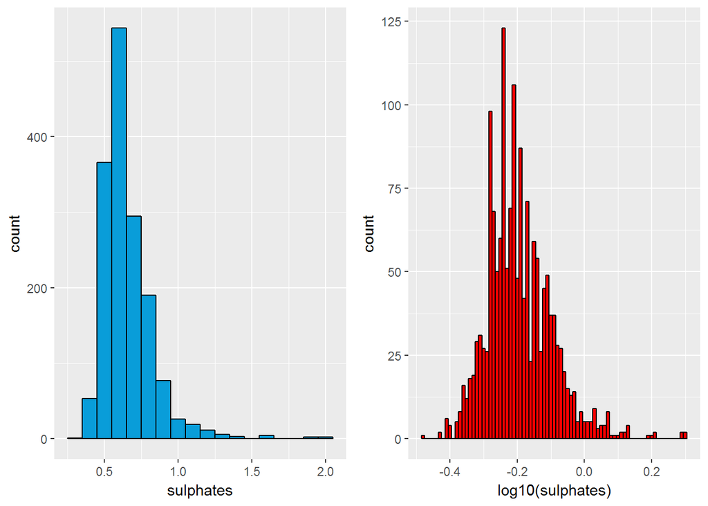

The Sulphates graph is skewed to the right, with a few outliers. This is the like some of the previous graphs we have seen. I implemented the log10 distribution, now we have a normal distribution curve.

### Alcohol

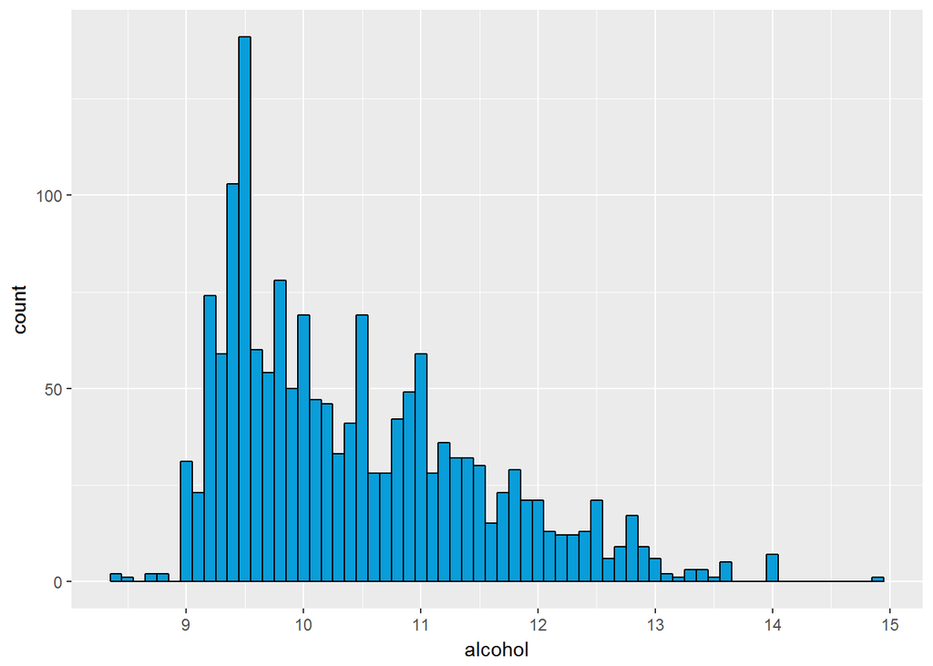

Alcohol is another right skewed graph, with the bulk of the data ranging from 9.5 - 10.5.

### Quality

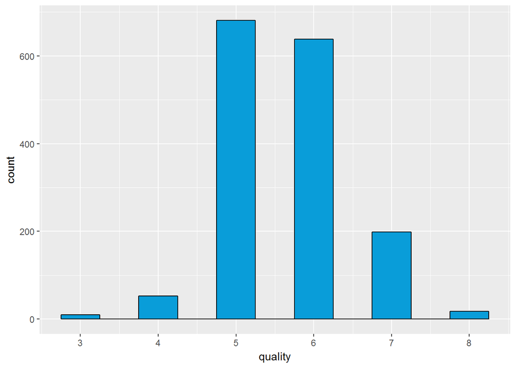

The range of quality is 3 through 8, but most of the ranking is 5 and 6, with the others as smaller pieces of the ranking. Overall, normal distribution curve.

# Univariate Analysis

### What is the structure of your dataset?

There are 1,599 observations(types of red wines), 13 total variables. 11 variables that describe chemical characteristics and the other 2 variables are quality and ID.

### What is/are the main feature(s) of interest in your dataset?

The main feature that I am interested in the dataset is how each wine ranked in regards to the quality of the wine. I will be trying to find out the factors that are contributors to higher quality ranked wines veruses lower quality wines.

### What other features in the dataset do you think will help support yourinto your feature(s) of interest?

Features that will help support my analysis will be alcohol content, sugar, acidity levels and density. My belief is that each of these chemicals will play a role in how the quality of red wine is determined.

### Did you create any new variables from existing variables in the dataset?

I did not. I believe that I can use the existing variables within the dataset to convey my answer.

### Of the features you investigated, were there any unusual distributions? you perform any operations on the data to tidy, adjust, or change the form the data? If so, why did you do this?

# Bivariate Plots Section

### Correlations with quality and sugar.

```
##                      residual.sugar
## X                      -0.031260835
## fixed.acidity           0.114776724
## volatile.acidity        0.001917882
## citric.acid             0.143577162
## residual.sugar          1.000000000
## chlorides               0.055609535
## free.sulfur.dioxide     0.187048995
## total.sulfur.dioxide    0.203027882
## density                 0.355283371
## pH                     -0.085652422
## sulphates               0.005527121
## alcohol                 0.042075437
## quality                 0.013731637
```

```
##                          quality
## X                     0.06645261
## fixed.acidity         0.12405165
## volatile.acidity     -0.39055778
## citric.acid           0.22637251
## residual.sugar        0.01373164
## chlorides            -0.12890656
## free.sulfur.dioxide  -0.05065606
## total.sulfur.dioxide -0.18510029
## density              -0.17491923
## pH                   -0.05773139
## sulphates             0.25139708
## alcohol               0.47616632
## quality               1.00000000
```

Looking at correlations, the highest correlations with quality are alcohol, volatile.acidity, sulphates, citric.acid. The highest correclations with sugar are density, total.sulfur.dioxide, free.sulfur.dioxide and citric.acid.

I will be looking at 6 different variables and matching them to the overall quality: - Alcohol Content - Residual Sugar - Volatile Acidity - Sulphates - Citric Acid - Density

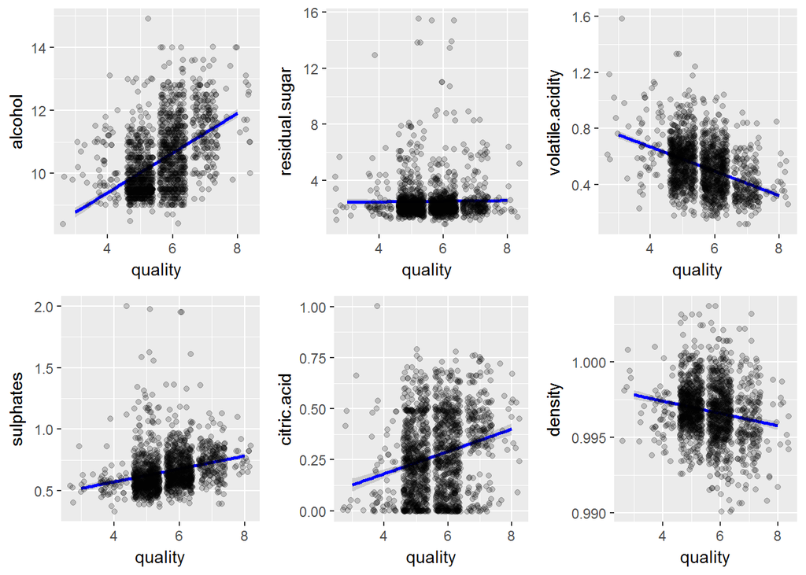

### Sugar versus 4 Different Variables

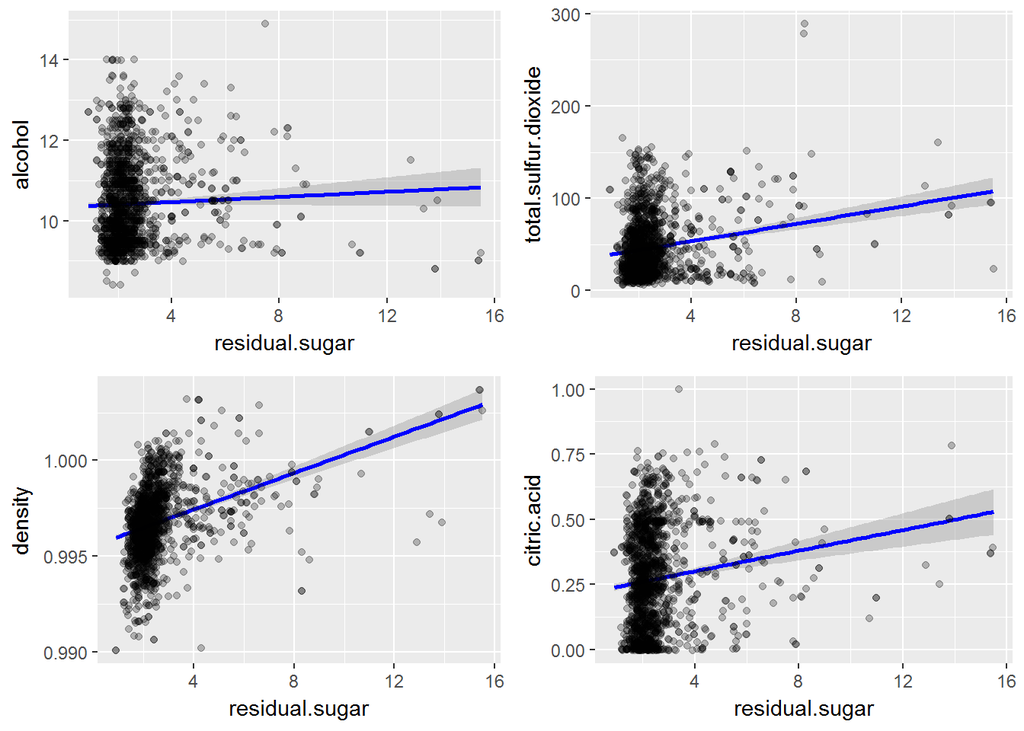

# Bivariate Analysis

### Talk about some of the relationships you observed in this part of the investigation. How did the feature(s) of interest vary with other features in the dataset?

In this dataset, I was looking to see what are the main features that go into higher ranked red wines. With plots that were plotted and the correlation that was done, the most that I could for see that would make a significant impact was alcohol. Also, seeing that the higher rated quality of wine the less dense it is.

### Did you observe any interesting relationships between the other features (not the main feature(s) of interest)?

What was interesting to me was looking at the correleation between density and alcohol content, then looking at density versus sugar. Density is negatively correlated to alcohol but has a positive correlation with sugar.

### What was the strongest relationship you found?

The strongest relationship that I found was between quality and alcohol. I had a correlation coefficient of 0.476 and with this information, we can assume that the more alcohol the wine has, the better ranked quality it will receive.

# Multivariate Plots Section

### Sugar vs Alcohol for quality

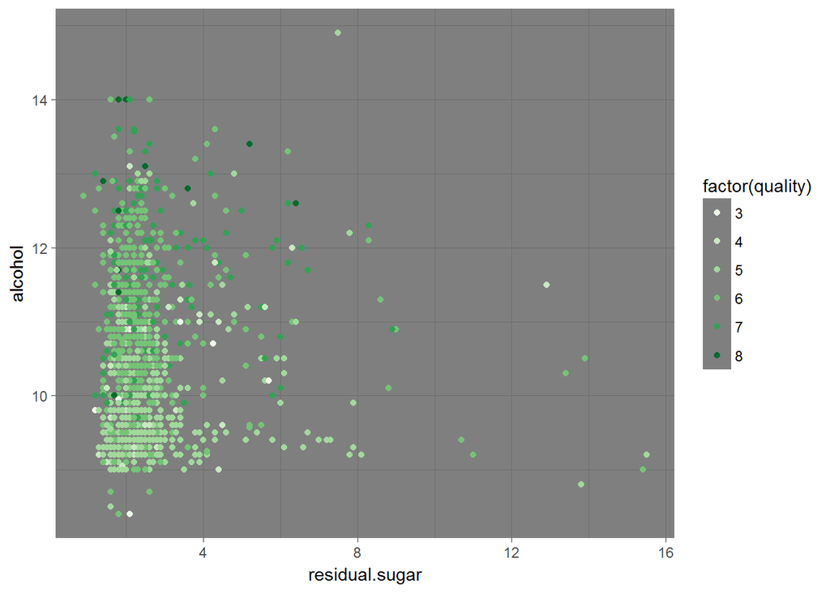

### Density vs Alcohol with quality

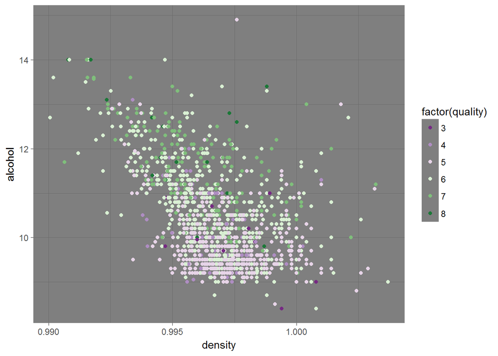

In regards to density in relationship with alcohol content and quality of wine, the lower dense the wine, the higher alcohol content and higher quality of wine.

### Sugar vs Density with quality

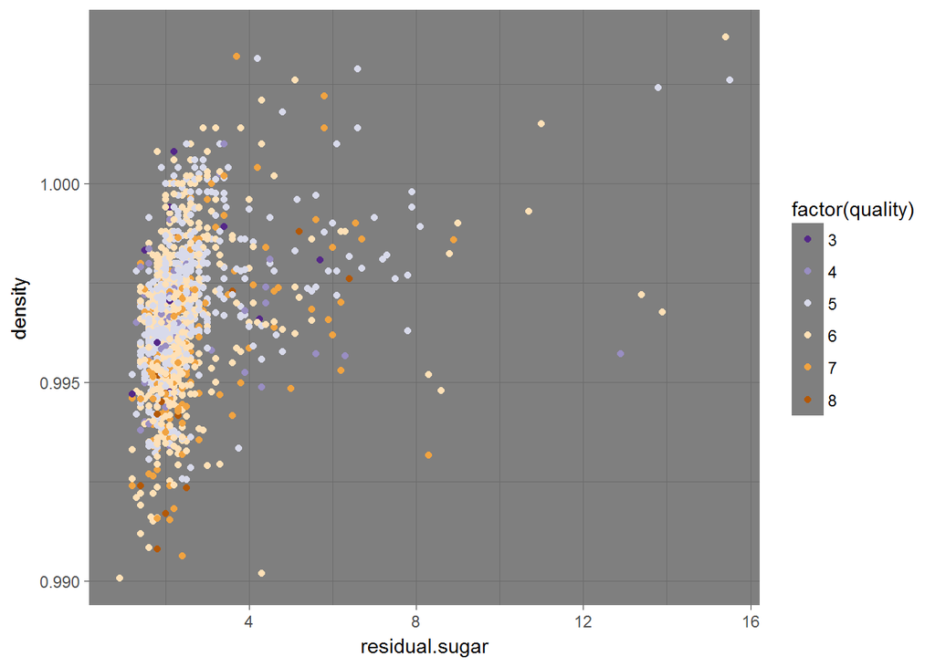

# Multivariate Analysis

### Were there any interesting or surprising interactions between features?

From the previous analysis conduct, there were not a good amount of surprising elements. Since I enjoy sweet wines that are not very dense and the analysis told the story to keep looking that direction, I wanted to press more on the density portion and sugar in wines, but at the end, there was nothing out of the oridinary.

# Final Plots and Summary

### Plot One

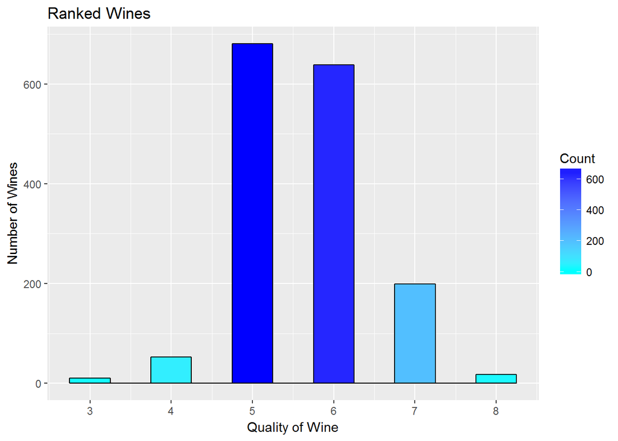

### Description One

The first plot is just a quick, clean view of demonstrating the amount of ranked wines within the red wine dataset. From here, it is a good view that we can only go from 3 - 8 in ranks and see where the most observations are held.

### Plot Two

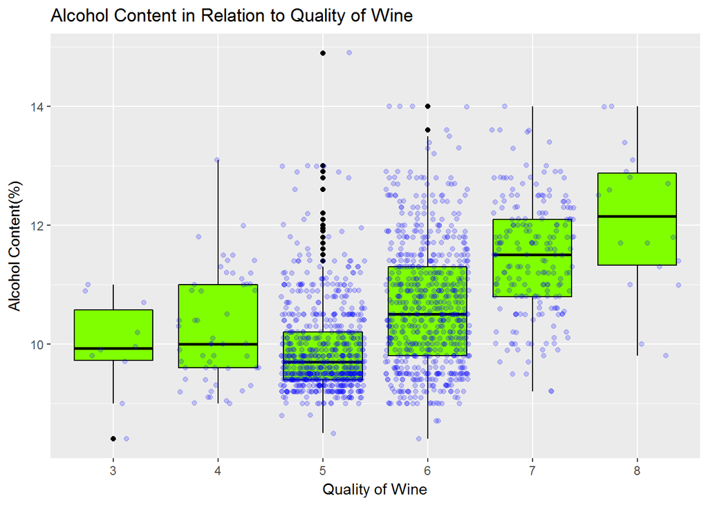

### Description Two

The trend of this plot states that the higher the alcohol content, the higher in quality of wine. It is an easy conclusion that alcohol content is a main contributor of how wines receive certain qualities.

### Plot Three

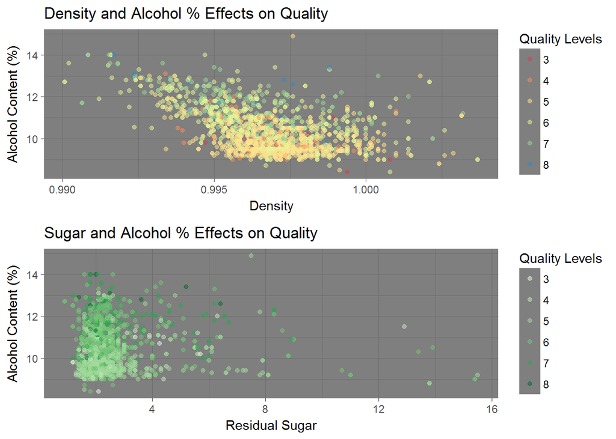

# Reflection

I enjoyed Exploraroty Data Analysis of Red Wines. I just did not learn about red wines and how they receive their quality rank, but a more in depth way to use R and how I could use this in my day to day work. I did struggle at times with this analysis on which variables to plot in relation to another variable, on top of the best plot to use(box, point, bar, line, etc). There are quite a few variables within this dataset, this was another struggle, due to trying to determine different trends for everything. It is difficult to look at every variable, graph each variable in relation to another and detemrine trends, data overload.

For the future, since “red” wine is just a type of wine, it would be interesting to see which type of “red” wine compares to each(Merlot, Pinor Noir, Zinfandel, etc.). Looking at specific wines will be interesting in see how those are ranked.